# Regression Analysis

3. Simple Linear Regression | Special Lecture for KINS

Boncho Ku, Ph.D. in Statistics

secondmoon@kiom.re.kr

Digital Health Research Division

Korea Institute of Oriental Medicine

2026-09-01

# Simple Linear Regression

## 두 변수 간 관계 측정

### 관계의 측도

두 변수 사이의 관계는 **방향**과 **강도** 두 가지로 요약

- **방향**: $x$가 커질 때 $y$도 커지는가(양의 연관성), 반대로 작아지는가(음의 연관성)
- **강도**: 그 경향이 얼마나 또렷한가
- 재는 방법은 여럿이나, 이 강의에서는 Pearson의 공분산과 상관계수를 씀

### 표기

관측 $n$개가 짝을 이루어 $(x_1,y_1),\dots,(x_n,y_n)$ 로 나타남

$$\bar y=\frac{1}{n}\sum_{i=1}^{n} y_i,\qquad \bar x=\frac{1}{n}\sum_{i=1}^{n} x_i$$

- $y_i$: $i$번째 관측의 반응변수, $x_i$: 같은 관측의 설명변수
- $n$: 관측 수, $\bar y,\bar x$: 표본평균(값을 모두 더해 개수로 나눈 값)

숫자 요약보다 **산점도**(관측 하나를 가로축 $x$, 세로축 $y$의 점 하나로 찍은 그림)를 먼저 볼 것

## 공분산의 착안: 편차의 곱

### 사분면의 쏠림

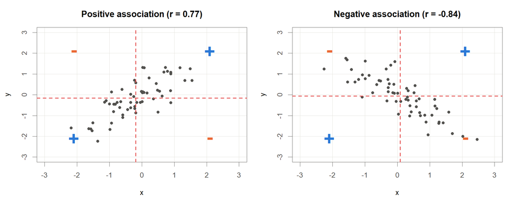

Sign of the deviation product in each quadrant

| Quadrant | $y_i-\bar y$ | $x_i-\bar x$ | Product |
| --- | --- | --- | --- |
| 1 (upper right) | $+$ | $+$ | $+$ |
| 2 (upper left) | $+$ | $-$ | $-$ |
| 3 (lower left) | $-$ | $-$ | $+$ |
| 4 (lower right) | $-$ | $+$ | $-$ |

**부호의 논리**

- 두 평균선이 평면을 넷으로 나눔
- 점 하나마다 두 편차를 곱하면 칸마다 부호가 정해짐
- 그림의 파란 $+$, 주황 $-$ 가 이 표의 마지막 열
- 두 그림에서 부호 배치는 **동일**. 다른 것은 점이 몰린 칸뿐

## 공분산: 정의

### 관찰의 수식화

**양의 연관성**

- 1, 3사분면에 점이 많음
- 두 편차의 **곱이 양수**인 칸들
- 모두 더하면 **양수**

**음의 연관성**

- 2, 4사분면에 점이 많음
- 두 편차의 **곱이 음수**인 칸들
- 모두 더하면 **음수**

**공분산(covariance)**

$$\operatorname{cov}(y,x)=\frac{1}{n-1}\sum_{i=1}^{n}(y_i-\bar y)(x_i-\bar x)$$

- $(y_i-\bar y)$: $y$ 가 평균에서 떨어진 거리, $(x_i-\bar x)$: $x$ 가 평균에서 떨어진 거리
- 두 편차의 곱을 모두 더해 $n-1$ 로 나눔. 모집단 공분산과 구별하여 **표본공분산**이라 부름

## 공분산의 한계와 표준화

### 주의: 단위 의존성

상수 $a,b,c,d$에 대해 $\operatorname{cov}(ay+b,\;cx+d)=ac\,\operatorname{cov}(y,x)$ 가 성립한다.

- $y$ 의 단위를 바꾸어 값에 $a$ 를 곱하면 공분산도 $a$ 배
- 키를 cm로 재느냐 inch로 재느냐에 따라 연관성의 크기가 달라진다면 곤란
- 공분산은 **부호는 믿을 수 있으나 크기는 단위에 좌우**되는 척도

### 해결: 표준화

$$z_i=\frac{y_i-\bar y}{s_y},\qquad s_y=\sqrt{\frac{1}{n-1}\sum_{i=1}^{n}(y_i-\bar y)^2}$$

- $s_y$: 표본표준편차(자료가 평균에서 떨어진 정도를 대표하는 값, 원자료와 단위가 같음)
- $z_i$: 표준화된 값. 편차를 흩어짐의 크기로 나누면 단위가 사라지고 $\bar z=0$, $s_z=1$

## 상관계수: 정의와 성질

### 표준화한 공분산

$$r=\operatorname{corr}(y,x)=\frac{1}{n-1}\sum_{i=1}^{n}\left(\frac{y_i-\bar y}{s_y}\right)\left(\frac{x_i-\bar x}{s_x}\right)=\frac{\operatorname{cov}(y,x)}{s_y\,s_x}$$

- $s_y$, $s_x$: 각각 $y$와 $x$의 표본표준편차
- 표준화한 두 변수의 공분산이 곧 상관계수
- 모집단 상관계수와 구별하여 **표본상관계수**라 부름

### 성질

- 측정 단위를 바꾸어도 값이 변하지 않음: $\operatorname{corr}(ay+b,\;cx+d)=\operatorname{corr}(y,x)$ ($ac>0$)
- $-1\le r\le 1$
- 부호는 방향, 절댓값은 강도. $1$ 또는 $-1$에 가까울수록 강한 **선형**관계
- $\operatorname{corr}(y,x)=\operatorname{corr}(x,y)$

## 상관계수: $r=0$ 의 함정

### $r=0$ 과 독립의 구분

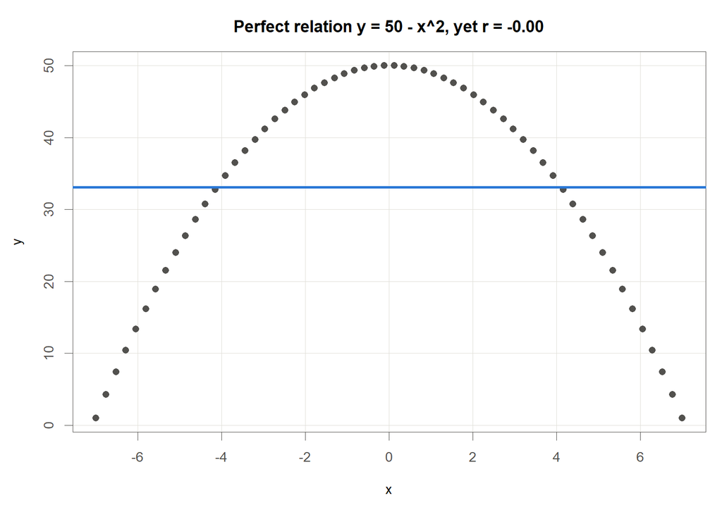

A perfect relation y = 50 - x<sup>2</sup> with correlation r = 0

$y=50-x^2$ 는 $x$가 정해지면 $y$가 완전히 결정되는 관계이나, 표본상관계수는 $r=0$ 이다.

- 상관계수는 **선형** 연관성만 재는 척도
- $r=0$ 은 “선형관계가 없다”는 뜻이지 “관계가 없다”는 뜻이 아님
- 따라서 숫자보다 산점도를 먼저 볼 것

## 상관계수: 산점도와 상관계수

### 산점도 형태에 따른 상관계수

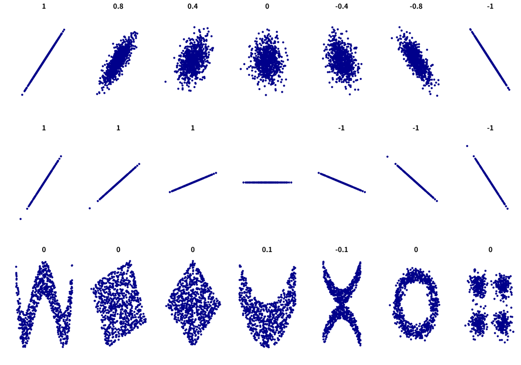

## 예제 자료: 아이스크림 소비량

### 자료 구조와 공분산·상관계수

First five of n = 30 four-week periods; 6 variables in total

| period | IC | price | income | temp | year |
| --- | --- | --- | --- | --- | --- |
| 1 | 0.386 | 0.270 | 78 | 41 | 0 |
| 2 | 0.374 | 0.282 | 79 | 56 | 0 |
| 3 | 0.393 | 0.277 | 81 | 63 | 0 |
| 4 | 0.425 | 0.280 | 80 | 68 | 0 |
| 5 | 0.406 | 0.272 | 76 | 69 | 0 |

Variables of the ice cream data

| Variable | Meaning |
| --- | --- |
| period | Observation index (four-week period) |
| IC | Per-capita ice cream consumption (pints) |
| price | Price of ice cream |
| income | Income |
| temp | Mean temperature (°F) |
| year | Observation year code (0/1/2) |

한 행은 4주 기간 하나이며, 총 $n=30$개 기간. 이 장에서 쓰는 변수는 $y_i=$ IC, $x_i=$ temp 두 개

Summary statistics of the two variables used in this chapter (n = 30)

| Statistic | temp ($x$) | IC ($y$) |
| --- | --- | --- |
| Mean | 49.1 | 0.359 |
| Standard deviation | 16.4 | 0.0658 |

$$\operatorname{cov}(y,x)=0.838,\qquad r=\frac{\operatorname{cov}(y,x)}{s_y\,s_x}=\frac{0.838}{0.0658\times 16.4}=\frac{0.838}{1.08}=0.776$$

- 부호가 양수이므로 온도가 높은 기간에 소비량도 큼
- $r=0.776$ 은 1에 비교적 가까우므로 선형관계가 뚜렷함
- 공분산 $0.838$ 자체의 크기는 단위에 좌우되므로 강도 판단에 쓰지 않음

## 단순선형회귀모형

### 정의

$$y_i=\beta_0+\beta_1 x_i+\varepsilon_i,\qquad i=1,\dots,n$$

- $y_i$: 반응변수, $x_i$: 설명변수, $\beta_0$: 절편, $\beta_1$: 기울기
- $\varepsilon_i$: 직선으로 설명되지 않는 오차(평균 0, 분산 $\sigma^2$)
- $\beta_0,\beta_1$ 은 값을 모르지만 **고정된 상수**. $y_i$ 가 흔들리는 원인은 오직 $\varepsilon_i$

### 계수의 뜻

- $\beta_1$ (기울기): $x$가 1단위 커질 때 $y$가 **평균적으로** 변하는 양
- $\beta_0$ (절편): $x=0$일 때 예측되는 $y$의 평균
- 적합된 직선은 조건부 기댓값 $E(y\mid x)=\beta_0+\beta_1x$의 추정이므로, 개별 관측이 아닌 **평균**에 관한 진술
- $x=0$이 자료 범위 밖이면 절편을 물리적으로 해석하지 않는 편이 안전함

## 후보 직선의 비교

### 무수히 많은 후보 직선

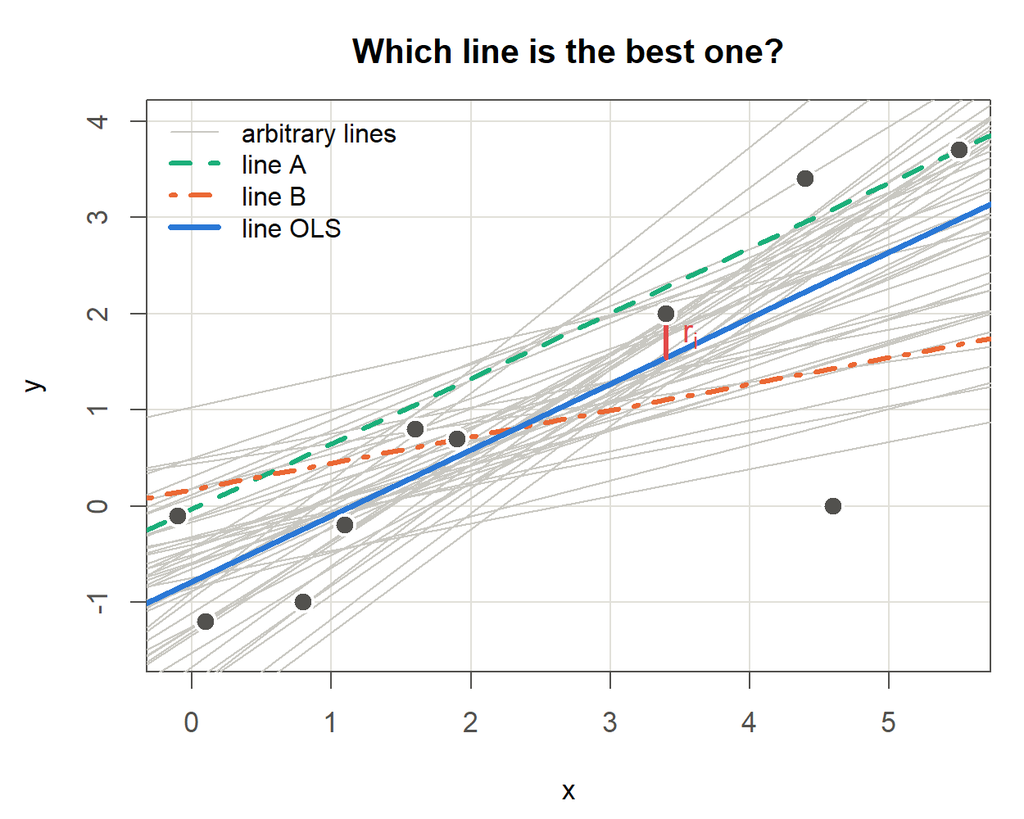

Infinitely many lines pass through the same scatter. Which one should be called the best?

**임의의 직선과 잔차**

$$r_i=y_i-(a_0+a_1x_i)$$

- $a_0,a_1$: 임의로 정한 직선의 절편과 기울기
- $r_i$: 그 직선에서 $i$번째 점까지의 세로 간격
- 직선을 하나 정할 때마다 잔차가 $n$개 생김. 좋은 직선은 이 $n$개가 **전체적으로 작은** 직선
- 두 직선의 우열을 가리려면 잔차 $n$개를 **하나의 수**로 요약해야 함. 이 요약값이 **기준**(criterion)
- 기준을 정해야 비로소 무수한 후보에 **순서**가 매겨지고 최적이라는 말이 정의됨

## 최소제곱 기준

### 그림으로 보기

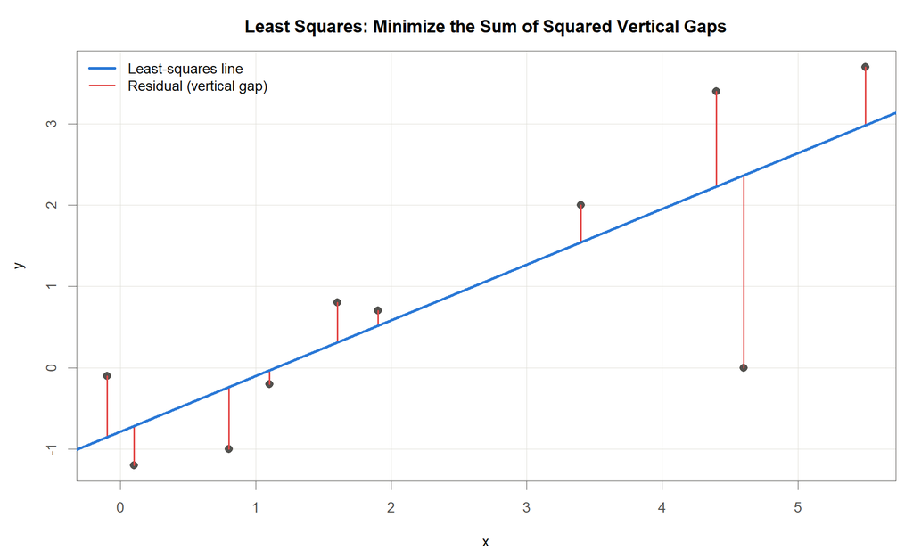

Least squares minimizes the sum of squared vertical gaps

**잔차** $e_i=y_i-\hat y_i$

**기호**

- $\hat y_i$: 직선이 예측한 값(적합값)
- $e_i$: 관측값과 적합값의 수직 간격

**최소제곱 기준**

$$\min_{\beta_0,\beta_1}\;\sum_{i=1}^{n}\left(y_i-\beta_0-\beta_1x_i\right)^2$$

이 제곱 합을 가장 작게 만드는 직선을 최적 직선으로 정의. 이를 **통상최소제곱법**(Ordinary Least Squares, OLS)이라 부름

## 제곱합을 기준으로 삼는 이유

### 네 직선, 세 기준

Four candidate lines scored by three criteria on the same 10 points. Bold marks the minimum of each criterion.

| 후보 직선 | 식 | $\sum r_i$ | $\sum\lvert r_i\rvert$ | $\sum r_i^2$ |
| --- | --- | --- | --- | --- |
| A: 양 끝점을 이음 | $-0.0321+0.679x$ | −7.39 | 8.28 | 14.8 |
| B: 평균점을 지나되 완만 | $0.172+0.274x$ | 0.00 | 10.3 | 15.5 |
| C: 절대편차합 최소 | $-0.883+0.833x$ | −2.48 | **6.25** | 10.8 |
| **OLS: 제곱합 최소** | $-0.786+0.685x$ | 0.00 | 7.55 | **9.38** |

- $\sum r_i$ 는 **순서를 매기지 못함**. B와 OLS가 모두 0이며, 평균점 $(\bar x,\bar y)$ 를 지나는 직선은 예외 없이 0이므로 무수히 많은 직선이 동점
- $\textstyle\sum(y_i-a_0-a_1x_i)=n(\bar y-a_0-a_1\bar x)$ 이므로, $a_0=\bar y-a_1\bar x$ 이면 기울기 $a_1$ 이 무엇이든 합은 0
- 기준이 바뀌면 답도 바뀜. $\sum\lvert r_i\rvert$ 의 최소는 C, $\sum r_i^2$ 의 최소는 OLS로 **서로 다른 직선**

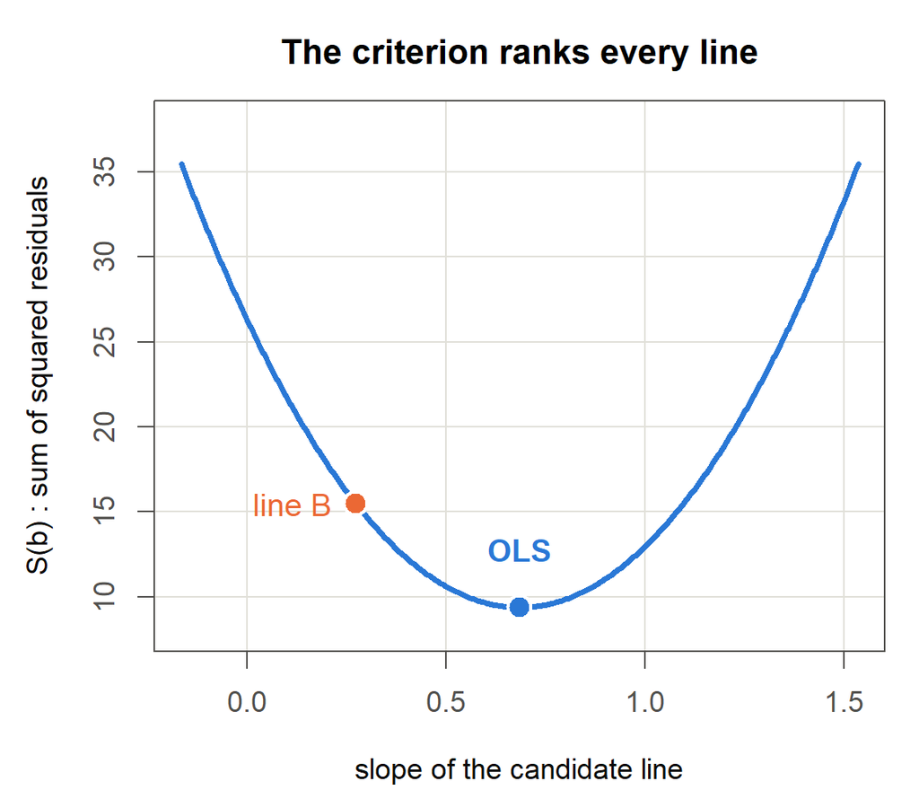

The sum of squared residuals as the candidate slope varies, with the intercept set to its best value at each slope.

**제곱합을 표준으로 삼는 근거**

- **해가 닫힌 형태로 존재**: $S(b)$ 가 $b$ 의 이차함수이자 아래로 볼록이므로 미분해 0으로 놓으면 유일한 최소점을 얻음(다음 장)
- **Gauss-Markov 정리**: 오차의 평균이 0이고 등분산·무상관이면, $y$ 의 선형결합으로 만든 불편추정량 가운데 분산이 가장 작음(BLUE)
- **정규오차에서 최대가능도와 일치**: $\varepsilon_i\sim N(0,\sigma^2)$ 이면 가능도를 최대화하는 것이 곧 제곱합을 최소화하는 것(두 슬라이드 뒤에서 유도)
- 다만 $\sum\lvert r_i\rvert$ 기준은 **이상점에 덜 민감**하여 로버스트 회귀에서 쓰임. 제곱합이 유일한 정답은 아님

## 최소제곱법: 정규방정식

### 두 편미분을 0으로

목적함수를 $S(\beta_0,\beta_1)=\sum_{i=1}^{n}(y_i-\beta_0-\beta_1x_i)^2$ 라 두면, 최소점에서 두 편미분이 모두 0

$$\begin{aligned}
\frac{\partial S}{\partial\beta_0} &= -2\sum_{i=1}^{n}(y_i-\beta_0-\beta_1x_i)=0\\
\frac{\partial S}{\partial\beta_1} &= -2\sum_{i=1}^{n}x_i(y_i-\beta_0-\beta_1x_i)=0
\end{aligned}$$

정리하면 미지수가 둘인 연립방정식, 곧 **정규방정식**

## 최소제곱법: 해의 유도

### 두 식, 두 미지수

1. **첫 식에서 절편이 바로 나온다.** 괄호를 풀어 항별로 더하면 $\sum y_i=n\beta_0+\beta_1\sum x_i$. 양변을 $n$ 으로 나누면 평균끼리의 관계가 되고, 이것이 곧 절편의 식
   $$\sum_{i=1}^{n}(y_i-\beta_0-\beta_1x_i)=0\;\Longrightarrow\;\bar y=\beta_0+\beta_1\bar x\;\Longrightarrow\;\hat\beta_0=\bar y-\hat\beta_1\bar x$$
2. **그 절편을 둘째 식에 대입한다.** 둘째 식은 $\sum x_iy_i=\beta_0\sum x_i+\beta_1\sum x_i^2$. 여기에 $\beta_0=\bar y-\beta_1\bar x$ 와 $\sum x_i=n\bar x$ 를 넣고 $\beta_1$ 이 든 항만 한쪽으로 모음
   $$\sum x_iy_i-n\bar x\bar y=\beta_1\!\left(\sum x_i^2-n\bar x^2\right)$$
3. **양변이 편차의 제곱합이다.** 괄호를 전개하면 $\sum x_iy_i-n\bar x\bar y=S_{xy}$, $\;\sum x_i^2-n\bar x^2=S_{xx}$ 이므로 양변을 $S_{xx}$ 로 나누면 기울기가 나옴

$$\hat\beta_1=\frac{S_{xy}}{S_{xx}},\qquad \hat\beta_0=\bar y-\hat\beta_1\bar x$$

**기호**: 앞으로 계속 쓸 세 제곱합은 모두 **평균에서의 편차**로 정의됨. $S_{xx}=\sum(x_i-\bar x)^2$, $S_{xy}=\sum(x_i-\bar x)(y_i-\bar y)$, $S_{yy}=\sum(y_i-\bar y)^2$

## 최소제곱법: 해의 성질

### 평균점 통과

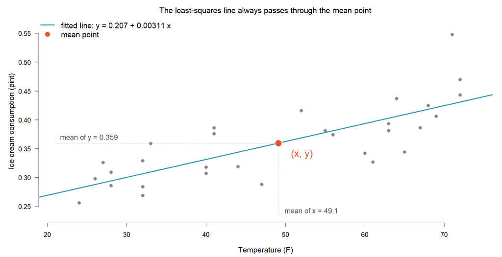

Least-squares fit of ice cream consumption on temperature, with the mean point marked

- 절편 식 $\hat\beta_0=\bar y-\hat\beta_1\bar x$ 를 옮기면 $\bar y=\hat\beta_0+\hat\beta_1\bar x$, 곧 $x=\bar x$ 에서의 적합값이 정확히 $\bar y$. 확인 $0.207+0.00311\times 49.1=0.359=\bar y$
- 첫 번째 정규방정식으로부터 잔차의 합은 항상 0: $\sum_{i=1}^{n}e_i=0$. 따라서 잔차의 평균도 0이며, 직선은 자료의 한가운데를 지나감

## 최대가능도법의 착안

### 정의

**최대가능도법**(maximum likelihood, 최대우도법): 지금 주어진 자료가 가장 나올 법하게 만드는 모수값을 고르는 방법. 가능도(likelihood)라는 함수를 정의하고, 그 함수가 최대가 되는 모수값을 찾음

확률을 말하려면 오차에 분포가 필요. $\varepsilon_i\stackrel{\text{iid}}{\sim}N(0,\sigma^2)$ 이면 $y_i\sim N(\beta_0+\beta_1x_i,\;\sigma^2)$ (iid: 서로 독립이고 같은 분포)

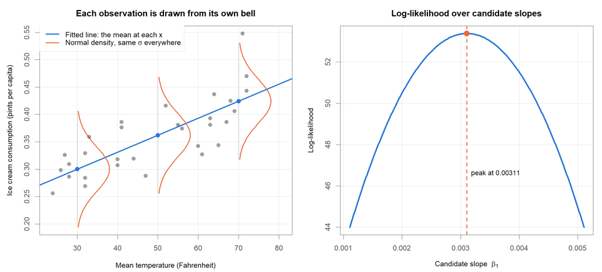

The normal-error model (left) and the log-likelihood over candidate slopes (right)

## 최대가능도 추정: 유도

### 가능도에서 정규방정식까지

1. **밀도를 모두 곱한다.** 관측이 서로 독립이므로 정규밀도 $n$개의 곱이 **가능도**. 자료를 고정하고 모수를 변수로 본 함수이며, 지수를 모으면 앞 슬라이드의 제곱합 $S(\beta_0,\beta_1)=\sum_{i=1}^{n}(y_i-\beta_0-\beta_1x_i)^2$ 이 저절로 등장
   $$\begin{aligned}
   L(\beta_0,\beta_1,\sigma^2)&=\prod_{i=1}^{n}\frac{1}{\sqrt{2\pi\sigma^2}}
   \exp\!\left\{-\frac{(y_i-\beta_0-\beta_1x_i)^2}{2\sigma^2}\right\}\\[2pt]
   &=(2\pi\sigma^2)^{-n/2}\exp\!\left\{-\frac{S(\beta_0,\beta_1)}{2\sigma^2}\right\}
   \end{aligned}$$
2. **로그를 취한다.** 로그는 증가함수이므로 최대점의 위치가 바뀌지 않음. $\beta_0,\beta_1$ 이 들어 있는 항은 마지막 하나뿐
   $$\ell(\beta_0,\beta_1,\sigma^2)=-\frac{n}{2}\ln(2\pi)-\frac{n}{2}\ln\sigma^2-\frac{1}{2\sigma^2}S(\beta_0,\beta_1)$$
3. **계수 앞의 부호를 본다.** 그 계수 $-\dfrac{1}{2\sigma^2}$ 는 항상 **음수**이므로, $\ell$ 을 $\beta_0,\beta_1$ 로 미분해 0으로 놓으면 앞 슬라이드의 **정규방정식이 그대로 나옴**

$$\ell \text{ 을 최대화}\;\Longleftrightarrow\;S(\beta_0,\beta_1)\text{ 을 최소화}$$

## 최대가능도 추정: 결과

### 최소제곱과의 비교

$\sigma^2$ 에 대해서는 $\dfrac{\partial\ell}{\partial\sigma^2}=-\dfrac{n}{2\sigma^2}+\dfrac{S}{2(\sigma^2)^2}=0$ 이므로 $\hat\sigma^2_{ML}=S(\hat\beta_0,\hat\beta_1)/n$

Simple regression of IC on temp, n = 30. The two criteria give the same line.

| Quantity | Least squares | Maximum likelihood |
| --- | --- | --- |
| $\hat\beta_1$ | 0.003107 | 0.003107 |
| $\hat\beta_0$ | 0.206862 | 0.206862 |
| $\hat\sigma^2$ | $S/(n-2)=0.0500/28=0.001786$ | $S/n=0.0500/30=0.001667$ |

- **절편과 기울기는 동일**
- $E(\hat\sigma^2_{ML})=\frac{n-2}{n}\sigma^2$: **편향추정량**
- 정규가정이 있으면 최소제곱은 **가장 그럴듯한 직선**이기도 함. 앞서 제곱합을 택한 세 번째 근거가 여기서 증명됨
- 표준오차·검정·신뢰구간에는 자유도를 반영한 불편추정량 $S/(n-2)$ 를 씀. $\hat\sigma^2_{ML}$ 은 뒤의 AIC 계산에 쓰임
- 정규가정이 깨지면 두 기준은 **갈라짐**. 이때는 가정에 맞는 가능도를 세워 최대화(일반화선형모형)

## 공분산, 상관계수, 회귀계수의 관계

### 핵심: 아래 세 표현은 모두동일

$$\hat\beta_1=\frac{S_{xy}}{S_{xx}}=\frac{\operatorname{cov}(y,x)}{\operatorname{var}(x)}=r\,\frac{s_y}{s_x}$$

- $\operatorname{var}(x)=s_x^2$: $x$의 표본분산
- $r$: 표본상관계수

**유도**

- $S_{xy}=(n-1)\operatorname{cov}(y,x)$, $S_{xx}=(n-1)\operatorname{var}(x)$ 이므로 $(n-1)$ 이 약분
  $$\frac{S_{xy}}{S_{xx}}=\frac{(n-1)\operatorname{cov}(y,x)}{(n-1)\operatorname{var}(x)}=\frac{\operatorname{cov}(y,x)}{\operatorname{var}(x)}$$
- $\operatorname{cov}(y,x)=r\,s_y s_x$, $\operatorname{var}(x)=s_x^2$ 이므로 $s_x$ 가 한 번 더 약분
  $$\frac{\operatorname{cov}(y,x)}{\operatorname{var}(x)}=\frac{r\,s_y s_x}{s_x^2}=r\,\frac{s_y}{s_x}$$

**해석**

- 기울기 = 상관계수 $\times$ 흩어짐 비율 $s_y/s_x$
- 방향과 강도는 상관계수가, 단위와 눈금은 표준편차 비율이 결정
- 상관계수는 무단위, 기울기의 단위는 ($y$의 단위)/($x$의 단위)

## 적합 결과: 아이스크림 자료

### 직선 하나, 계산 경로 넷

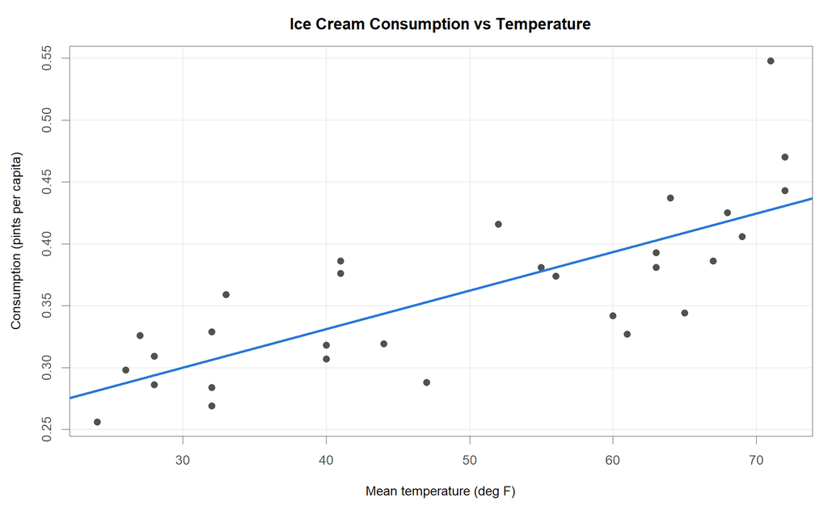

Ice cream consumption vs temperature with the fitted least-squares line

$$\hat y_i=\hat\beta_0+\hat\beta_1x_i,\qquad e_i=y_i-\hat y_i$$

$$\hat y=0.207+0.00311\,x$$

Fitted simple linear regression (IC on temp, n = 30)

| Term | Estimate | Interpretation |
| --- | --- | --- |
| $\hat\beta_0$ | 0.207 | Fitted IC at temp = 0 |
| $\hat\beta_1$ | 0.00311 | Mean change in IC per 1°F |

온도가 1°F 오를 때 소비량의 평균이 약 0.00311 증가. 자료에 temp = 0 인 관측이 없으므로 절편은 직선의 높이를 맞추는 값으로 읽음

Four routes to the same slope estimate (ice cream data, IC on temp, n = 30)

| Route | Expression | Input values | Slope |
| --- | --- | --- | --- |
| (1) Sums of squares | $S_{xy}/S_{xx}$ | $(n-1)$ cancels out | 0.00311 |
| (2) Covariance | $\operatorname{cov}(y,x)/s_x^2$ | $s_x^2=16.4^2=269$ | 0.00311 |
| (3) Correlation | $r\,s_y/s_x$ | $0.776\times 0.0658 / 16.4$ | 0.00311 |
| (4) Normal equations | $\hat\beta_1$ from $\bar y=\hat\beta_0+\hat\beta_1\bar x$ | n.a. | 0.00311 |

계산 경로가 서로 다른데도 네 값이 모두 일치함. 우연이 아니라 앞 장의 항등식이 성립한 결과

## Gauss-Markov 정리

### 최소분산 선형 불편추정량

오차의 평균이 0이고, 분산이 모두 $\sigma^2$ 로 같으며, 서로 무관하면, 최소제곱 추정량은 **선형 불편추정량 가운데 분산이 가장 작다**(BLUE, Best Linear Unbiased Estimator).

**정리가 말하지 않는 것**

- ’선형’은 $y$ 의 가중합으로 쓸 수 있다는 뜻. 비선형 추정량까지 포함해 최소라는 주장은 아님
- ‘불편’ 조건을 풀면 분산이 더 작은 **편향**추정량이 있을 수 있음(능형회귀 등)
- **정규분포 가정은 필요 없음**. 정규성은 $t$·$F$ 검정과 구간추정에서 비로소 필요
- 등분산이 깨지면 최소제곱은 여전히 불편이지만 최소분산은 아님 $\to$ 6장 가중회귀

## Gauss-Markov 정리: 경쟁자로 확인

### 두 집단 평균으로 만든 추정량

$x$ 의 중앙값에서 두 무리로 갈라 평균점끼리 이은 기울기 $\tilde\beta_1=(\bar y_H-\bar y_L)/d$. 무게 $d=\bar x_H-\bar x_L=29.53$ 이 $x$ 만으로 정해지므로 **선형**, $\sum a_i=0$·$\sum a_ix_i=1$ 이므로 **불편**. 분산이 $\hat\sigma^2\sum a_i^2$ 이고 $\hat\sigma^2$ 은 두 방법이 공유하므로 **가중치 제곱합**만 견주면 됨 (이 분산 공식과 $\sum c_i^2=1/S_{xx}$ 는 다음 두 장에서 유도)

$$\begin{aligned}
\text{두 집단 평균:}\quad \sum a_i^2&=\frac{1/n_H+1/n_L}{d^2}=1.529\times10^{-4}\\[2pt]
\text{최소제곱:}\quad \sum c_i^2&=\frac{1}{S_{xx}}=1.279\times10^{-4}
\end{aligned}$$

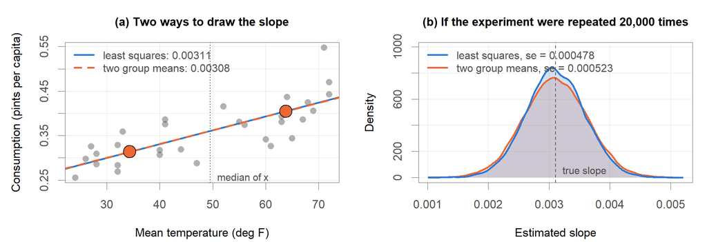

Least squares against a competing linear unbiased estimator (ice cream data, n = 30)

분산비 $1.529/1.279=\mathbf{1.196}$, 표준오차로는 $0.000478$ 대 $0.000523$. $\hat\sigma^2$ 이 약분되므로 이 비는 **자료의 흩어짐과 무관하게 가중치만으로** 결정됨

## 회귀계수의 불편성: 증명

### 기울기의 가중합 표현

1. **$\hat\beta_1$ 을 $y$ 의 가중합으로 고쳐 쓴다.** $S_{xy}$ 에서 $\bar y$ 가 붙은 항은 $\sum(x_i-\bar x)=0$ 이라 사라짐. 남은 가중치 $c_i$ 는 $x$ 만으로 정해지는 **상수**
   $$\hat\beta_1=\frac{S_{xy}}{S_{xx}}=\frac{\sum(x_i-\bar x)y_i}{S_{xx}}=\sum_{i=1}^{n}c_iy_i,
   \qquad c_i=\frac{x_i-\bar x}{S_{xx}}$$
2. **가중치의 두 성질을 확인한다.** 이 두 줄이 증명의 전부이며, 둘째 등식은 $\sum(x_i-\bar x)x_i=\sum x_i^2-n\bar x^2=S_{xx}$ 에서 나옴
   $$\sum c_i=\frac{\sum(x_i-\bar x)}{S_{xx}}=0,\qquad
   \sum c_ix_i=\frac{\sum(x_i-\bar x)x_i}{S_{xx}}=\frac{S_{xx}}{S_{xx}}=1$$
3. **기댓값을 취한다.** 모형이 $E(y_i)=\beta_0+\beta_1x_i$ 이므로 두 성질이 그대로 대입됨
   $$E(\hat\beta_1)=\sum c_iE(y_i)
   =\beta_0\underbrace{\sum c_i}_{=\,0}+\beta_1\underbrace{\sum c_ix_i}_{=\,1}=\beta_1$$
4. **절편은 따라 나온다.** $\hat\beta_0=\bar y-\hat\beta_1\bar x$ 이고 $E(\bar y)=\beta_0+\beta_1\bar x$ 이므로
   $$E(\hat\beta_0)=E(\bar y)-\bar x\,E(\hat\beta_1)=(\beta_0+\beta_1\bar x)-\bar x\beta_1=\beta_0$$

$$E(\hat\beta_0)=\beta_0,\qquad E(\hat\beta_1)=\beta_1$$

## 회귀계수의 분산과 공분산

### 같은 가중치의 활용

$$\operatorname{Var}(\hat\beta_1)=\frac{\sigma^2}{S_{xx}},\qquad
\operatorname{Var}(\hat\beta_0)=\sigma^2\!\left(\frac1n+\frac{\bar x^2}{S_{xx}}\right),\qquad
\operatorname{Cov}(\hat\beta_0,\hat\beta_1)=-\frac{\sigma^2\bar x}{S_{xx}}$$

**유도**: 관측이 서로 무관하고 분산이 모두 $\sigma^2$ 이므로 $\operatorname{Var}(\sum c_iy_i)=\sigma^2\sum c_i^2$ 이고, $\sum c_i^2=\sum(x_i-\bar x)^2/S_{xx}^2=1/S_{xx}$. 절편은 $\operatorname{Cov}(\bar y,\hat\beta_1)=\sigma^2\sum c_i/n=0$ 이라 두 항의 분산이 그대로 더해짐

여기서 $SSE=\sum_{i=1}^{n}e_i^2=\sum(y_i-\hat y_i)^2$ 는 **잔차제곱합**이며, $\hat\sigma^2$ 이 $\sigma^2$ 의 불편추정량이 되는 이유는 두 장 뒤에서 유도

Estimated variability of the two coefficients (n = 30, x-bar = 49.1, Sxx = 7820.7)

| Quantity | Formula | Ice cream (IC on temp) |
| --- | --- | --- |
| $\hat\sigma^2$ | $SSE/(n-2)$ | 0.0017860 |
| $\operatorname{se}(\hat\beta_1)$ | $\hat\sigma/\sqrt{S_{xx}}$ | 0.000478 |
| $\operatorname{se}(\hat\beta_0)$ | $\hat\sigma\sqrt{1/n+\bar x^2/S_{xx}}$ | 0.0247 |
| $\widehat{\operatorname{Cov}}(\hat\beta_0,\hat\beta_1)$ | $-\hat\sigma^2\bar x/S_{xx}$ | $-1.121\times10^{-5}$ |

- $S_{xx}$ 가 클수록 기울기의 분산이 작아짐. **설명변수를 넓게 잡으라**는 설계 지침이 여기서 나옴
- 절편의 분산에 $\bar x^2$ 이 들어 있는 이유: 절편은 $x=0$ 에서의 값인데 자료가 그 지점에서 멀수록 불확실. 이 자료의 온도 범위는 24~72 $^\circ$F 로 0을 포함하지 않음
- 공분산이 **음수**: 직선이 평균점 $(\bar x,\bar y)$ 를 반드시 지나므로, 기울기를 크게 잡으면 절편은 작게 잡힘

## Gauss-Markov 정리: 증명

### 경쟁자의 손해 $\sum d_i^2$

1. **경쟁자가 만족해야 할 조건을 적는다.** 다른 선형추정량 $\tilde\beta_1=\sum a_iy_i$ 가 **불편**이려면
   $$E(\tilde\beta_1)=\beta_0\sum a_i+\beta_1\sum a_ix_i=\beta_1
   \;\Longrightarrow\;\sum a_i=0,\qquad \sum a_ix_i=1$$
2. **최소제곱과의 차이를 $d_i$ 로 둔다.** $a_i=c_i+d_i$ 로 쓰면 위 조건과 $\sum c_i=0$, $\sum c_ix_i=1$ 에서 $d$ 쪽 두 성질이 나오고, 그것이 교차항을 없앰
   $$\sum d_i=0,\quad \sum d_ix_i=0
   \;\Longrightarrow\;\sum c_id_i=\frac{\sum d_ix_i-\bar x\sum d_i}{S_{xx}}=0$$
3. **가중치 제곱합을 전개한다.** $a_i=c_i+d_i$ 를 제곱해 더하면 세 덩어리가 나오는데, 가운데가 방금 구한 교차항이라 통째로 사라짐
   $$\sum a_i^2=\sum(c_i+d_i)^2=\sum c_i^2+2\underbrace{\sum c_id_i}_{=\,0}+\sum d_i^2
   =\sum c_i^2+\sum d_i^2$$
4. **분산으로 옮긴다.** $\sigma^2\sum c_i^2$ 이 곧 최소제곱의 분산이고, 뒤에 더해지는 몫은 제곱합이므로 **항상 0 이상**
   $$\operatorname{Var}(\tilde\beta_1)=\sigma^2\sum a_i^2
   =\underbrace{\sigma^2\sum c_i^2}_{=\;\operatorname{Var}(\hat\beta_1)}+\;\sigma^2\sum d_i^2$$

$$\operatorname{Var}(\tilde\beta_1)\ \ge\ \operatorname{Var}(\hat\beta_1),
\qquad \text{등호는 모든 } d_i=0,\ \text{곧 } \tilde\beta_1=\hat\beta_1 \text{ 일 때뿐}$$

## 오차분산의 추정: $E(\hat\sigma^2)=\sigma^2$

### 증명

1. **잔차를 편차의 꼴로 바꾼다.** $\hat\beta_0=\bar y-\hat\beta_1\bar x$ 를 넣으면 $e_i=(y_i-\bar y)-\hat\beta_1(x_i-\bar x)$, 제곱해 더한 뒤 $S_{xy}=\hat\beta_1S_{xx}$ 를 쓰면
   $$SSE=S_{yy}-2\hat\beta_1S_{xy}+\hat\beta_1^2S_{xx}=S_{yy}-\hat\beta_1^2S_{xx}$$
2. **앞 항의 기댓값.** 모형을 넣으면 $y_i-\bar y=\beta_1(x_i-\bar x)+(\varepsilon_i-\bar\varepsilon)$ 이고, 교차항의 기댓값은 0
   $$E(S_{yy})=\beta_1^2S_{xx}+\underbrace{E\textstyle\sum(\varepsilon_i-\bar\varepsilon)^2}_{=\,(n-1)\sigma^2}=\beta_1^2S_{xx}+(n-1)\sigma^2$$
3. **뒤 항의 기댓값.** $E(Z^2)=\operatorname{Var}(Z)+[E(Z)]^2$ 에 **앞 두 장의 결과** $\operatorname{Var}(\hat\beta_1)=\sigma^2/S_{xx}$, $E(\hat\beta_1)=\beta_1$ 을 대입
   $$E\!\left(\hat\beta_1^2S_{xx}\right)=\left(\frac{\sigma^2}{S_{xx}}+\beta_1^2\right)S_{xx}=\sigma^2+\beta_1^2S_{xx}$$
4. **빼면 $\beta_1$ 항이 상쇄된다.** $\bar y$ 에서 자유도 하나, $\hat\beta_1$ 에서 하나가 더 빠져 $n-2$
   $$E(SSE)=\big[\beta_1^2S_{xx}+(n-1)\sigma^2\big]-\big[\sigma^2+\beta_1^2S_{xx}\big]=(n-2)\sigma^2$$

$$\hat\sigma^2=\frac{SSE}{n-2}\;\Rightarrow\;E(\hat\sigma^2)=\sigma^2,
\qquad \hat\sigma^2_{ML}=\frac{SSE}{n}\;\Rightarrow\;E(\hat\sigma^2_{ML})=\frac{n-2}{n}\sigma^2$$

## 기울기의 표준오차

### 정의

$$\hat\sigma^2=\frac{SSE}{n-2},\qquad \operatorname{se}(\hat\beta_1)=\frac{\hat\sigma}{\sqrt{S_{xx}}}$$

- $\hat\sigma^2$: 오차분산 $\sigma^2$ 의 추정값, $\hat\sigma$: 잔차 표준오차
- $n-2$: 자유도. 관측 $n$ 개에서 추정한 계수 2개를 뺀 값
- $\operatorname{se}(\hat\beta_1)$: **표준오차**. 자료가 바뀔 때 $\hat\beta_1$ 이 흔들리는 폭의 추정값

**아이스크림 자료 계산**

$\hat\sigma^2=0.00179$, $\hat\sigma=0.0423$, $S_{xx}=(n-1)s_x^2=7820.7$

$$\operatorname{se}(\hat\beta_1)=\sqrt{\frac{\hat\sigma^2}{S_{xx}}}=\sqrt{\frac{0.00179}{7820.7}}=0.000478$$

$S_{xx}$가 클수록, 곧 설명변수가 넓게 퍼져 있을수록 기울기를 정밀하게 추정함.

## 회귀계수의 검정

### 정의

$$H_0:\beta_1=0\ (x\text{는 }y\text{를 설명하지 못함})\qquad\text{vs}\qquad H_1:\beta_1\neq 0$$

$$H_0:\beta_0=0\ (\text{직선이 원점을 지남})\qquad\text{vs}\qquad H_1:\beta_0\neq 0$$

$$t=\frac{\hat\beta_j}{\operatorname{se}(\hat\beta_j)}\ \sim\ t_{\,n-2}\quad(H_0\text{ 아래에서}),\qquad j=0,1$$

## 회귀계수 검정: 결과와 $p$값

### 아이스크림 자료

Tests of H0: coefficient = 0 for the ice cream data (IC on temp, n = 30, df = 28)

| Term | Estimate | $\operatorname{se}$ | $t$ | $p$-value |
| --- | --- | --- | --- | --- |
| $\hat\beta_0$ (intercept) | 0.20686 | 0.02470 | 8.37 | $4.1\times10^{-9}$ |
| $\hat\beta_1$ (temp) | 0.00311 | 0.000478 | 6.50 | $4.8\times10^{-7}$ |

각 $t$ 는 추정값을 자기 표준오차로 나눈 값이고, 자유도 28의 $t$분포에서 그 값의 양측 꼬리 면적이 $p$값

**$p$값 읽는 법**: $H_0$가 참이라는 **가정 아래** 지금 관측된 것만큼 또는 그보다 더 극단적인 결과가 나올 확률

- $4.8\times 10^{-7}$은 $1/(4.8\times10^{-7})\approx 2.1\times 10^{6}$, 곧 약 200만 번에 한 번꼴
- 따라서 $H_0$를 기각하고 온도가 소비량을 설명한다고 판단함
- **$p$값은 가설이 참일 확률이 아님**

## 결정계수 $R^2$: 변동의 분해

### 총변동의 분해

$$SST=SSR+SSE,\qquad R^2=\frac{SSR}{SST}=1-\frac{SSE}{SST}$$

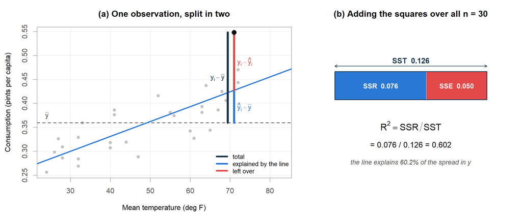

- $SST=\sum(y_i-\bar y)^2$ 총변동 · $SSR=\sum(\hat y_i-\bar y)^2$ 회귀로 설명된 변동 · $SSE=\sum(y_i-\hat y_i)^2$ 남은 변동
- $R^2$ = 총변동 가운데 직선이 설명한 비율, $0\le R^2\le 1$. 1에 가까울수록 직선이 흩어짐을 많이 설명

## 결정계수와 상관계수

### $R^2=r^2$

설명변수가 하나인 단순선형회귀에서 결정계수는 표본상관계수의 제곱과 같다.

$$R^2=\left[\operatorname{corr}(y,x)\right]^2=\left[\operatorname{corr}(y,\hat y)\right]^2$$

The coefficient of determination equals the squared correlation (IC on temp, n = 30)

| Quantity | Value |
| --- | --- |
| $r=\operatorname{corr}(y,x)$ | 0.776 |
| $r^2$ | 0.602 |
| $R^2$ of the fitted model | 0.602 |

**주의**

- $R^2$의 적정 수준에는 절대 기준이 없고 분야와 자료 유형에 따라 다름
- $R^2$만으로 모형의 좋고 나쁨을 단정하지 않으며, 잔차 진단과 함께 판단
- $R^2=r^2$ 라는 관계는 설명변수가 하나일 때의 성질이며, 다중회귀에서는 $y$와 적합값 $\hat y$의 상관계수 제곱으로만 성립

## 회귀분산분석: 표의 구조

### 제곱합과 자유도

앞의 $SST=SSR+SSE$ 를 자유도와 함께 표로 정리하면, 모형 전체를 한꺼번에 검정하는 통계량이 나온다.

Analysis of variance for simple linear regression

| Source | df | Sum of squares | Mean square | $F$ |
| --- | --- | --- | --- | --- |
| Regression | 1 | $SSR$ | $MSR=SSR/1$ | $MSR/MSE$ |
| Residual | $n-2$ | $SSE$ | $MSE=SSE/(n-2)$ |  |
| Total | $n-1$ | $SST$ |  |  |

**평균제곱(Mean square)** 은 제곱합을 자유도로 나눈 값, 곧 **자유도 하나당 변동**. 크기가 다른 두 제곱합을 견줄 수 있게 척도를 맞추는 작업이며, $MSE=\hat\sigma^2$ 은 앞에서 쓴 오차분산 추정값과 같은 것

- 가설은 $H_0:\beta_1=0$ 대 $H_1:\beta_1\neq 0$ 로 $t$ 검정과 같음. 단순회귀에서는 설명변수가 하나뿐이라 **모형 전체의 검정**과 **기울기 하나의 검정**이 같은 질문
- $H_0$ 가 참이면 $MSR$ 과 $MSE$ 가 모두 $\sigma^2$ 의 불편추정량이 되어 $F$ 는 1 근처. 설명한 몫이 커질수록 $F$ 가 커짐
- $H_0$ 아래에서 $F\sim F(1,\;n-2)$ 이며, 비이므로 **오른쪽 한쪽 꼬리만** 봄

## 회귀분산분석표: $F=t^2$ 확인

### 두 검정의 일치

Analysis of variance for the ice cream data (IC on temp, n = 30)

| Source | df | Sum Sq | Mean Sq | $F$ | $p$-value |
| --- | --- | --- | --- | --- | --- |
| Regression | 1 | 0.075514 | 0.075514 | 42.28 | $4.8\times10^{-7}$ |
| Residual | 28 | 0.050009 | 0.001786 |  |  |
| Total | 29 | 0.125523 |  |  |  |

**설명변수가 하나면 두 검정이 완전히 같다**

$$F=t^2:\qquad 6.5023^2=42.280,\qquad
F(0.95;1,28)=2.0484^2=4.196=\big[t(0.975;28)\big]^2$$

통계량도 임계값도 $p$값$(4.8\times10^{-7})$ 도 모두 일치. 설명변수가 둘 이상이면 이 관계는 깨지고, $F$ 는 계수 전체를 한꺼번에 묻는 별도의 검정이 됨

- 세로로 더해짐: $0.075514+0.050009=0.125523$, $1+28=29$
- $MSE=0.001786=\hat\sigma^2$ 이고 $\sqrt{MSE}=0.04226=\hat\sigma$ 가 잔차 표준오차
- $R^2=SSR/SST=0.075514/0.125523=0.6016$ 도 이 표에서 바로 읽힘

## 회귀계수의 신뢰구간

### 정의

$$\hat\beta_j\pm t_{\alpha/2,\,n-2}\,\operatorname{se}(\hat\beta_j),\qquad j=0,1$$

- $t_{\alpha/2,\,n-2}$: 자유도 $n-2$인 $t$분포의 임계값
- 이 구간이 $100(1-\alpha)\%$ **신뢰구간**

**아이스크림 자료의 95% 신뢰구간** ($\alpha=0.05$, 자유도 28, $t_{0.025,28}=2.048$)

$$\hat\beta_1:\; 0.00311\pm 2.048\times 0.000478=0.00311\pm 0.00098
\;\Rightarrow\;(0.00213,\;0.00409)$$

$$\hat\beta_0:\; 0.20686\pm 2.048\times 0.02470=0.20686\pm 0.05060
\;\Rightarrow\;(0.15627,\;0.25746)$$

두 구간 모두 0을 포함하지 않으므로 앞의 검정 결과와 일치함.

확률은 계수가 아니라 **구간을 만드는 절차**에 붙음. 해석의 자세한 내용은 2장 **신뢰구간** 참조

## 구간추정: 평균반응과 새 관측

### 두 구간의 차이

#### **신뢰구간 (평균반응)**

새 조건 $x_0$ 에서 조건부 기댓값 $E(y\mid x=x_0)$ 을 잡는 구간

$$\hat y_0\pm t_{\alpha/2,\,n-2}\;\hat\sigma\sqrt{\frac{1}{n}+\frac{(x_0-\bar x)^2}{S_{xx}}}$$

- $\hat y_0=\hat\beta_0+\hat\beta_1x_0$: 새 조건에서의 적합값
- $\hat\sigma$: 잔차 표준오차

#### **예측구간 (새 관측 하나)**

새로 관측될 값 $y_0$ 자체를 잡는 구간

$$\hat y_0\pm t_{\alpha/2,\,n-2}\;\hat\sigma\sqrt{1+\frac{1}{n}+\frac{(x_0-\bar x)^2}{S_{xx}}}$$

근호 안에 $1$이 더해지는 이유는 개별 관측의 오차 $\varepsilon_0$ 가 추가되기 때문. 따라서 **예측구간은 항상 신뢰구간보다 넓음**

## 두 구간의 수치 비교

### 아이스크림 자료, $x_0=65$

$\hat y_0=0.207+0.00311\times 65=0.409$, $\;\bar x=49.1$, $\;S_{xx}=7820.7$, $\;\hat\sigma=0.0423$, $\;t_{0.025,\,28}=2.048$

$$c=\frac{1}{n}+\frac{(x_0-\bar x)^2}{S_{xx}}=\frac{1}{30}+\frac{15.9^2}{7820.7}=0.0657$$

Two intervals for the ice cream data at temp = 65 (n = 30)

| Interval | Half-width | Result |
| --- | --- | --- |
| 신뢰구간 | $t\,\hat\sigma\sqrt{c}=0.0222$ | $(0.387,\;0.431)$ |
| 예측구간 | $t\,\hat\sigma\sqrt{1+c}=0.0893$ | $(0.319,\;0.498)$ |

예측구간의 폭이 신뢰구간의 약 4.0배. 근호 안의 $1$ 이 $0.0657$ 보다 압도적으로 크기 때문

두 구간 모두 $(x_0-\bar x)^2$ 항 때문에 $x_0$ 가 $\bar x$ 에서 멀어질수록 넓어짐. 자료 범위 밖으로 외삽하면 구간이 급격히 넓어짐

## 추정에서 검정까지: 계산 경로

### 자료에서 $t$ 통계량까지

$$S_{xx}=\sum_{i=1}^{n}(x_i-\bar x)^2=7820.7,\qquad S_{xy}=\sum_{i=1}^{n}(x_i-\bar x)(y_i-\bar y)=24.3$$

$$\hat\beta_1=\frac{S_{xy}}{S_{xx}}=\frac{24.3}{7820.7}=0.00311,\qquad
\hat\beta_0=\bar y-\hat\beta_1\bar x=0.207$$

$$\hat\sigma^2=\frac{\mathrm{SSE}}{n-2}=\frac{0.0500}{28}=0.00179,\qquad \hat\sigma=0.0423$$

$$\mathrm{SE}(\hat\beta_1)=\sqrt{\frac{\hat\sigma^2}{S_{xx}}}=\sqrt{\frac{0.00179}{7820.7}}=0.000478,\qquad
t=\frac{\hat\beta_1}{\mathrm{SE}(\hat\beta_1)}=6.50$$

## 계산 경로: 결과표와 각 항의 뜻

### 프로그램 출력표

Fitted model IC on temp; residual standard error 0.0423 on 28 degrees of freedom, R-squared 0.602

| Term | Estimate | SE | $t$ | $p$-value |
| --- | --- | --- | --- | --- |
| (Intercept) | 0.207 | 0.0247 | 8.37 | $4.1\times10^{-9}$ |
| temp | 0.00311 | 0.000478 | 6.50 | $4.8\times10^{-7}$ |

**각 항의 뜻**

- **Estimate**: 최소제곱 정규방정식의 해 $\hat\beta_j$
- **SE**: $\hat\beta_1$ 의 표집분포의 표준편차 $\hat\sigma/\sqrt{S_{xx}}$. $S_{xx}$ 가 클수록 작아짐
- **$t$**: 추정값을 그 표준오차 단위로 잰 값. $H_0$ 아래에서 자유도 $n-2=28$ 의 t분포를 따름
- **$p$-value**: $H_0:\beta_1=0$ 에 대한 양측 검정의 유의확률
- **$R^2$**: $0.602=0.776^2$, 곧 상관계수의 제곱. 단순회귀에서만 성립하는 항등식

## 이 장의 정리

### Simple Linear Regression

**관계를 잰다**(공분산과 상관계수로 방향과 강도) $\to$ **직선을 긋는다**(수직 간격의 제곱 합이 최소) $\to$ **계수를 읽는다**($x$ 1단위당 $y$의 평균 변화) $\to$ **불확실성을 확인한다**($R^2$, $t$검정, 구간).

Summary of the four quantities of simple linear regression

| Concept | Formula | Ice cream data |
| --- | --- | --- |
| Covariance | $\frac{1}{n-1}\sum(y_i-\bar y)(x_i-\bar x)$ | 0.838 |
| Correlation | $\operatorname{cov}(y,x)/(s_ys_x)$ | 0.776 |
| Slope | $r\,s_y/s_x=S_{xy}/S_{xx}$ | 0.00311 |
| Coefficient of determination | $1-SSE/SST=r^2$ | 0.602 |

상관계수와 회귀 기울기는 같은 정보를 다른 눈금으로 표현한 값. 계수는 언제나 표준오차 또는 구간과 함께 보고할 것

오차에 정규분포를 가정하면 최소제곱 직선이 곧 **최대가능도 추정**. 회귀계수는 같고 오차분산만 $S/(n-2)$ 와 $S/n$ 으로 갈림

**다음 장**: Multiple Linear Regression: 온도 하나로 설명한 60% 외에 남은 40%는 무엇이 설명하는가. 설명변수를 여럿으로 확장

## 참고문헌

### 교과서

- Kutner, M. H., Nachtsheim, C. J., Neter, J., & Li, W. (2005). *Applied Linear Statistical Models*, 5th ed. McGraw-Hill.
- Faraway, J. J. (2015). *Linear Models with R*, 2nd ed. CRC Press.